# Statistical Models for Network Graphs in R

Angela Andreella Ca’ Foscari University of Venice angela.andreella@unive.it

2024-07-02

# 1 Introduction

Here, we will see how to apply some **Exponential Random Graph Models** (ERGM) which are designed in direct analogy to the classical Generalized Linear Models (GLMs).

Other famous models:

- **Stochastic block models** draws their inspiration from mixture models.
- **Latent network models** are a network-based variant of the common practice of using both observed and unobserved (i.e., latent) variables in modeling an outcome (i.e., in this case, the presence or absence of network edges).

see “Statistical Analysis of Network Data with R” by Kolaczyk, E. D., and Csárdi, G. (2014) (Chapter 6).

# 2 Exponential Random Graph Models

The goal of ERGMs is to *describe parsimoniously the local selection forces that shape the global structure of a network* ([Hunter et al. 2008](https://www.tandfonline.com/doi/abs/10.1198/016214507000000446)).

ERGMs are analogous to logistic regression: they predict the **probability that a pair of nodes in a network will have a tie between them**, but they have some important differences from standard regression methods, e.g., observations (nodes and edges) are **interdependent**.

Let $Y_{ij} = Y_{ji}$ be a binary random variable indicating the presence or absence of an edge $e \in E$ between the two vertices $i$ and $j$ in $V$.

The matrix $\mathbf{Y} = [Y_{ij}]$ is simply the (random) adjacency matrix for $G$.

$$\Pr(\mathbf{Y} = \mathbf{y} \mid \theta, \mathcal{Y}) = \dfrac{1}{k
(\theta, \mathcal{Y})} \exp\Big\{\theta^\top g(\mathbf{y},
\mathbf{X}) \Big\}$$

where

- $\theta$ is a vector of **coefficients**,
- $g(\mathbf{y}, \mathbf{X})$ is a vector of **sufficient statistics**,
- $\mathcal{Y}$ is the **space of possible graphs**, and
- $k(\theta, \mathcal{Y})$ is a **normalizing constant**.

$k(\theta, \mathcal{Y})$ is the numerator summed across all possible graphs $\mathcal{Y}$. For even moderate-sized graphs, $k(\theta, \mathcal{Y})$ can be enormous, so closed-form solutions are unfeasible. The number of labeled, undirected graphs of $V_n$ vertices is $2^{V_n(V_n-1)/2}$, which can get big fast.

The basic assumption of these models is that the structure in an observed graph $\mathbf{y}$ can be explained by a given vector of sufficient statistics $g(\mathbf{y})$ which are a function of the observed network and, in some cases, nodal attributes, i.e., $g(\mathbf{y}, \mathbf{X})$.

To fit an ERGM, we use the `ergm` package, which is part of the `statnet` suite of packages.

```r
rm(list = ls())
library(statnet)
library(sand) #to load the lazega data
library(ergm)
data(lazega)
```

Since `ergm` uses the `network` package to represent network objects, we convert the `igraph` object to the format used in `statnet` using the `asNetwork` function from `intergraph` package.

```r
library(intergraph)
lazega.ergm <- asNetwork(lazega)
lazega.ergm
```

```
##  Network attributes:
##   vertices = 36
##   directed = FALSE
##   hyper = FALSE
##   loops = FALSE
##   multiple = FALSE
##   bipartite = FALSE
##   total edges= 115
##     missing edges= 0
##     non-missing edges= 115
##
##  Vertex attribute names:
##     Age Gender Office Practice School Seniority Status vertex.names Years
##
## No edge attributes
```

The `lazega` dataset shows the **collaborative working relationships among members of a New England law firm**. These data were collected for the purpose of **studying cooperation among social actors in an organization**, through the exchange of various types of resources among them. The organization observed was a law firm, consisting of over $70$ lawyers (roughly half partners and the other half associates) in three offices located in three different cities. Relational data reflecting resource exchange were collected, and additional attribute information was recorded for each lawyer, including type of practice, gender, and seniority.

- `Gender`: 1 is man, 2 is woman
- `Office`: 1 is Boston, 2 is Hartford, 3 is Providence
- `Years`: years with the firm
- `Age`
- `Practice`: 1 is litigation, 2 is corporate
- `School`: 1 is Harvard or Yale, 2 is University of Connecticut, 3 other

Let look at the dataset:

```r
v.names <- vertex_attr_names(lazega)
sapply(v.names, function(x) table(vertex_attr(lazega, x)))
```

```
## $name
##
##  V1 V10 V11 V12 V13 V14 V15 V16 V17 V18 V19  V2 V20 V21 V22 V23 V24 V25 V26 V27
##   1   1   1   1   1   1   1   1   1   1   1   1   1   1   1   1   1   1   1   1
## V28 V29  V3 V30 V31 V32 V33 V34 V35 V36  V4  V5  V6  V7  V8  V9
##   1   1   1   1   1   1   1   1   1   1   1   1   1   1   1   1
##
## $Seniority
##
##  1  2  3  4  5  6  7  8  9 10 11 12 13 14 15 16 17 18 19 20 21 22 23 24 25 26
##  1  1  1  1  1  1  1  1  1  1  1  1  1  1  1  1  1  1  1  1  1  1  1  1  1  1
## 27 28 29 30 31 32 33 34 35 36
##  1  1  1  1  1  1  1  1  1  1
##
## $Status
##
##  1
## 36
##
## $Gender
##
##  1  2
## 33  3
##
## $Office
##
##  1  2  3
## 22 13  1
##
## $Years
##
##  1  5  7  8  9 10 11 13 15 16 17 18 19 20 21 22 23 24 25 28 29 31 32
##  1  1  1  5  1  1  1  2  3  1  1  1  2  1  1  1  2  1  2  1  2  3  1
##
## $Age
##
## 33 34 36 37 38 39 41 43 44 45 46 47 48 49 50 52 53 55 56 57 59 62 63 64 67
##  2  1  1  1  2  1  1  3  1  2  2  1  1  2  2  1  3  1  1  1  2  1  1  1  1
##
## $Practice
##
##  1  2
## 20 16
##
## $School
##
##  1  2  3
## 12 11 13
```

So, let make a first plot, where the size of the nodes is proportional to the `Years` values covariates:

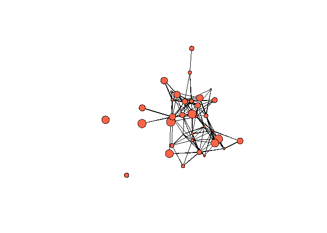

```r
years <- lazega.ergm %v% 'Years'
# %v% references vertex attributes,
#equivalent to get.vertex.attribute(lazega.ergm, "Years")
#from igraph.

plot(lazega.ergm,
     vertex.col = "tomato",
     vertex.cex = years/10)
```

With our data ready for analysis using `statnet`, let’s build our first ERGM. There are a number of potential ERGM terms that we could use in fitting our model. You can view a full list by looking at the documentation for:

```r
?ergm.terms
```

## 2.1 A Bernoulli model

We begin with the simplest possible model: one that assumes **every tie is equally likely**.

This ERGM contains only one term that represents the total number of edges in the network, $\sum y_{ij} = N_e$.

The name of this `ergm-term` is `edges`, and when included in an ERGM **its coefficient controls the overall density of the network**. It is a statistic which counts how many edges there are in the network.

The ERGM model is then:

$$\Pr (\mathbf{Y} = \mathbf{y} \mid \theta, \mathcal{Y}) = \dfrac{1}{k
(\theta, \mathcal{Y})} \exp\Big\{\theta \sum y_{ij} \Big\}$$
assuming $\theta_{i j}$ equal to some common value $\theta$ (typically referred to as an assumption of **homogeneity** across the network),

We can compute the edge statistic for this network:

```r
summary(lazega.ergm ~ edges)
```

```
## edges
##   115
```

and then we estimate the ERGM model as:

```r
random_graph <- ergm(lazega.ergm ~ edges)
```

This model fits very **quickly**, and we have the same result every time we run it.

This is because this model contains **no dependency terms**, i.e., terms that model how the probability of a tie between two nodes is affected by **existing ties** in the network.

In models without dependency terms, the ERGM solution can be approximated without simulation, using MPLE (maximum pseudo-likelihood estimator). This is basically fitting a logistic regression to our network ties.

**How do we interpret this coefficient?**

Coefficients in ERGMs represent the change in the (log-odds) likelihood of an edge being present between two actors, holding the rest of the network fixed for a unit change in a predictor, i.e.,

$$\text{logit}(\Pr(Y_{ij} = 1 \mid \mathbf{y}_{-(ij)})) = -1.4992 \,\,
\delta(y_{ij})$$

where $\delta(y_{ij})$ is a vector of the **change statistics** for each model term. The change statistic records how the $g(\mathbf{y})$ term changes having $y_{ij}=1$ and $y_{ij}=0$.

> 💥 How much is $\delta(y_{ij})$ having only `edges` as `ergm-terms`?

As in `lm` and `glm`, we can extract the estimated coefficient with:

```r
theta <- coef(random_graph)
theta
```

```
##     edges
## -1.499235
```

> 💥 so?

We can interpret directly in terms of probability instead of log-odds:

```r
inv.logit <- function(logit){
  odds <- exp(logit)
  prob <- odds / (1 + odds)
  return(prob)
}

inv.logit(theta)
```

```
##     edges
## 0.1825397
```

So the probability of an edge being in the graph is roughly $0.18$. The probability of an edge being drawn should in theory be the same as **density** - let’s check.

```r
network.density(lazega.ergm)
```

```
## [1] 0.1825397
```

We can more closely examine the model fit using the `summary()` function, just like `lm()` or `glm()` in base R.

```r
summary(random_graph)
```

```
## Call:
## ergm(formula = lazega.ergm ~ edges)
##
## Maximum Likelihood Results:
##
##       Estimate Std. Error MCMC % z value Pr(>|z|)
## edges  -1.4992     0.1031      0  -14.54   <1e-04 ***
## ---
## Signif. codes:  0 '***' 0.001 '**' 0.01 '*' 0.05 '.' 0.1 ' ' 1
##
##      Null Deviance: 873.4  on 630  degrees of freedom
##  Residual Deviance: 598.8  on 629  degrees of freedom
##
## AIC: 600.8  BIC: 605.2  (Smaller is better. MC Std. Err. = 0)
```

We can also simulate graphs using our ERGM fit.

```r
set.seed(1234)
hundred_simulations <- simulate(random_graph,
                  coef = theta,
                  nsim = 100,
                  control = control.simulate.ergm(MCMC.burnin = 1000, #number of proposals before any MCMC sampling is done.
                                                  MCMC.interval = 1000)) #Number of proposals between sampled statistics
```

Let’s examine the first three simulations.

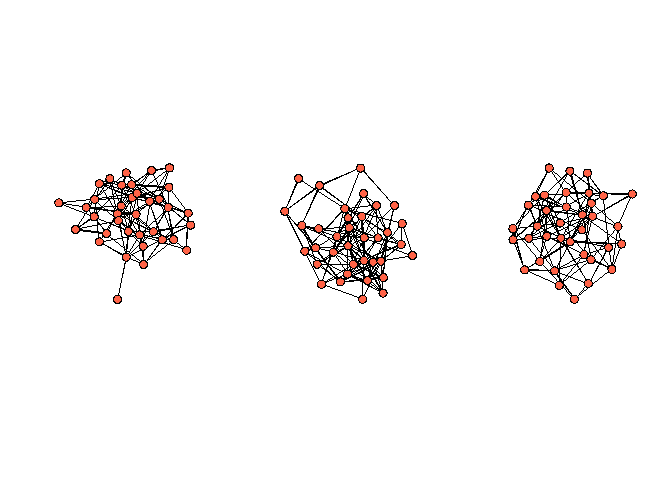

[output not shown]

[output cut: 58 more lines]

```r
par(mfrow = c(1, 3))
sapply(hundred_simulations[1:3], plot, vertex.cex = 3, vertex.col = "tomato")
```

We can compare the number of edges our observed graph has to the average of the simulated networks.

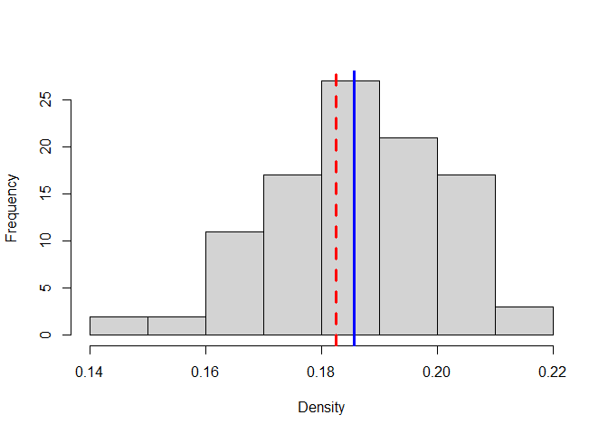

```r
net_densities <- unlist(lapply(hundred_simulations, network.density))

hist(net_densities, xlab = "Density", main = "", col = "lightgray")
abline(v = network.density(lazega.ergm), col = "red", lwd = 3, lty = 2)
abline(v = mean(net_densities), col = "blue", lwd = 3, lty = 1)
```

For ERGMs, the current practice in assessing goodness-of-fit is to first **simulate numerous random graphs from the fitted model** and then compare high-level **characteristics** of these graphs, i.e.,:

- degree
- edge-wise shared partners (i.e., the number of neighbors shared by a pair of vertices defining an edge)
- geodesic distance

with those of the originally observed graph.

If the characteristics of the observed network graph are too poor of a match to the typical values arising from realizations of the fitted random graph model, then this suggests systematic differences between the specified class of models and the data, and therefore a lack of goodness-of-fit.

To assess the goodness-of-fit of our model, as fit by ergm, the function `gof` in `ergm` runs the necessary Monte Carlo simulation and calculates these comparisons:

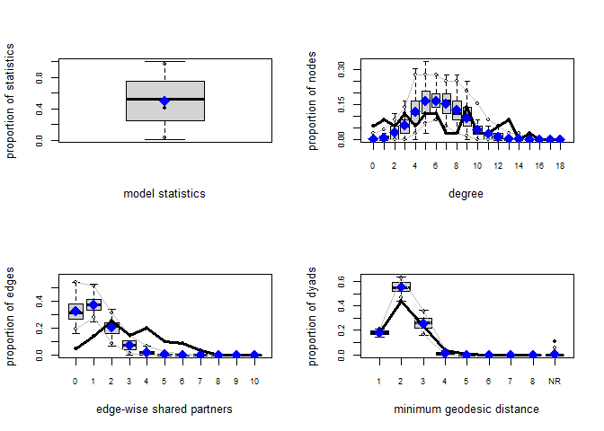

```r
gof_stats <- gof(random_graph,coef = theta)

par(mfrow = c(2, 2))
plot(gof_stats, main = '')
```

> 💥 What do you think?

How to we improve our fit? By adding more terms to the model!

## 2.2 Triad formation

It is of interest to incorporate higher order statistics associated with the overall structure of the network, such as the number of $k$-stars ($k+1$ vertices and $k$ edges) $S_k(\mathbf{y})$ (`kstar`) and the number of (3-clique) triangles $T(\mathbf{y})$ (`triangle`).

Triangles measure **transitivity** and **clustering** in networks. We can add a triangle term to our `ergm`. Unlike the edges-only model, this model will need to be estimated via MCMC, deriving from the fundamental work of [Geyer and Thompson](https://academic.oup.com/jrsssb/article-abstract/54/3/657/7035848?redirectedFrom=fulltext&login=false). See [Hunter and Handcock](https://www.tandfonline.com/doi/abs/10.1198/106186006X133069), for example, for additional details and references.

So, let look at the $g(\mathbf{y})$ stats for this model

```r
summary(lazega.ergm~edges+triangle) #
```

```
##    edges triangle
##      115      120
```

and the we fit the model

```r
tr_graph <- ergm(lazega.ergm ~ edges + triangles)
```

Whenever `ergm` fits a model via MCMC, you will get a warning telling you to check for **degeneracy** and model diagnostics.

In general, triangles cause problems in ERGMs, i.e., degeneracy. While our intuition tells us that triangles should matter for networks – because triangles result from transitivity – it turns out that there are **better ways** to represent transitivity in network models.

Triadic structures are highly constrained by the number of edges and the size of the network, which jointly determine the network density. This situation of extreme constraint causes the MCMC algorithm by which ergms are estimated to behave badly, leading to the condition of degeneracy discussed above.

A network model is degenerate when the space that an MCMC sampler can explore is so constrained that the only way to get the observed is essentially to flicker between full and empty graphs in the right proportion. Not what you want out of an MCMC estimator. A good indication that you have a degenerate model is that you have `NA` values for standard errors on your ergm parameter estimates. You can’t calculate a variance – and, therefore, a standard error – if you simply flicker between full and empty graphs.

## 2.3 Nodal Covariates

It is natural to expect that the chance of an edge joining two vertices depends not only on the status (i.e., presence or absence) of edges between other vertex pairs, but also on **attributes** of the vertices themselves (i.e., allowing for assessment of exogenous effects).

The vertex attributes can be included in the formulation of an ERGM by means of

$$g(\mathbf{x}, \mathbf{y}) = \sum_{i < j} y_{ij}h(\mathbf{x}_i,
\mathbf{x}_j)$$

where $h(\cdot)$ is a symmetric function, and $\mathbf{x}_i$ is the observed vector of node $i$ attributes.

So, we can express two effects:

- **Main effect**: `nodecov`, $h(x_i, x_j) = x_i + x_j$
- **Second order effect**, homophily (i.e., the tendency of similar individuals to associate with each other): `nodematch`, $h(x_i, x_j) = \mid x_i + x_j \mid$.

So, here we want an ERGM with:

- Main effect for `Practice`, i.e., the type of practice can influence the formation of ties
- Second order effect for `Practice`, `Gender`, and `Office`, i.e, individuals with similar values of these attributes tends to form links with each other.
- and a transitivity measure, i.e., the **Geometrically Weighted Edgewise Shared Partner** (GWESP). It is a measure of the tendency of nodes to form triangles, that is, to share common partners.

As before, let compute the observed stats:

```r
summary(lazega.ergm ~ edges + gwesp(log(3), fixed=TRUE)
 + nodecov("Practice")
 + nodematch("Practice")
 + nodematch("Gender")
 + nodematch("Office"))
```

```
##                        edges gwesp.fixed.1.09861228866811
##                     115.0000                     222.9108
##             nodecov.Practice           nodematch.Practice
##                     359.0000                      72.0000
##             nodematch.Gender             nodematch.Office
##                      99.0000                      85.0000
```

In `gwesp(log(3), fixed=TRUE)`, the argument $\log(3)$ is a decay value that controls how quickly the effect of shared partners decreases as the number of such partners increases. The `fixed=TRUE` argument indicates that the decay parameter is fixed at the specified value, rather than being estimated from the data.

So, let fit the model:

```r
lazega.ergm.fit <- ergm(lazega.ergm ~ edges + gwesp(log(3), fixed=TRUE)
 + nodecov("Practice")
 + nodematch("Practice")
 + nodematch("Gender")
 + nodematch("Office"))
```

So, this specification allows us to control for the density of the network and some effects of **transitivity**. In addition, it allows us to assess the effect on the formation of collaborative ties among lawyers that is had by the type of practice (i.e., corporate or litigation), and commonality of practice, gender, and office location.

We can also use the `anova` function:

```r
anova(lazega.ergm.fit)
```

|  | Df | Deviance | Resid. Df | Resid. Dev | Pr(>\|Chisq\|) |
| --- | --- | --- | --- | --- | --- |
| NULL | NA | NA | 630 | 873.3654 | NA |
| Model 1: | 6 | 397.1431 | 624 | 476.2224 | 1.149901e-82 |

As before, we can examine the relative contribution of the individual variables in our model.

```r
summary(lazega.ergm.fit)
```

```
## Call:
## ergm(formula = lazega.ergm ~ edges + gwesp(log(3), fixed = TRUE) +
##     nodecov("Practice") + nodematch("Practice") + nodematch("Gender") +
##     nodematch("Office"))
##
## Monte Carlo Maximum Likelihood Results:
##
##                              Estimate Std. Error MCMC % z value Pr(>|z|)
## edges                        -5.14302    0.46548      0 -11.049  < 1e-04 ***
## gwesp.fixed.1.09861228866811  0.60645    0.08335      0   7.276  < 1e-04 ***
## nodecov.Practice              0.25552    0.09095      0   2.810 0.004961 **
## nodematch.Practice            0.72590    0.18720      0   3.878 0.000105 ***
## nodematch.Gender              0.34757    0.22592      0   1.539 0.123924
## nodematch.Office              0.90808    0.18542      0   4.897  < 1e-04 ***
## ---
## Signif. codes:  0 '***' 0.001 '**' 0.01 '*' 0.05 '.' 0.1 ' ' 1
##
##      Null Deviance: 873.4  on 630  degrees of freedom
##  Residual Deviance: 476.2  on 624  degrees of freedom
##
## AIC: 488.2  BIC: 514.9  (Smaller is better. MC Std. Err. = 0.3478)
```

Again, in order to interpret the coefficients, it is useful to think in terms of the probability of a given vertex pair having an edge, conditional on the edge status between all other pairs.

Writing $\mathbf{Y}_{(−i j)}$ to be all of the elements of $\mathbf{Y}$ except $Y_{i j}$, the distribution of $Y_{i j}$ conditional on $\mathbf{Y}_{(-i j)}$ is Bernoulli and satisfies the expression:

$$\log\Big[ \dfrac{\Pr_{\theta}(Y_{ij} = 1 \mid \mathbf{Y}_{(-ij)}=
\mathbf{y}_{(-ij)})}{\Pr_{\theta}(Y_{ij} = 0 \mid \mathbf{Y}_{(-ij)}=
\mathbf{y}_{(-ij)})}\Big] = \theta^\top \Delta_{ij}(\mathbf{y})$$

where $\Delta_{ij}(\mathbf{y})$ is the *change statistic*, denoting the difference between $\mathbf{g}(\mathbf{y})$ when $y_{i j} = 1$ and when $y_{i j} = 0$.

For example, practicing corporate law, rather than litigation, increases the odds of cooperation by a factor of $\exp(0.259) \approx 1.3$.

Similarly, being from the same office more than doubles the odds of cooperation, since $\exp(0.9)\approx 2.46$.

Since the `gwesp` coefficient is positive (and strongly significant) we can say there is a positive tendency towards **triadic closure**. Thus, the more shared partners between two nodes, the more likely those nodes are to be connected.

In all cases, such statements hold in the sense of **all else being equal** (i.e., given no change among values of the other statistics).

Finally, we must check the goodness of fit of the model:

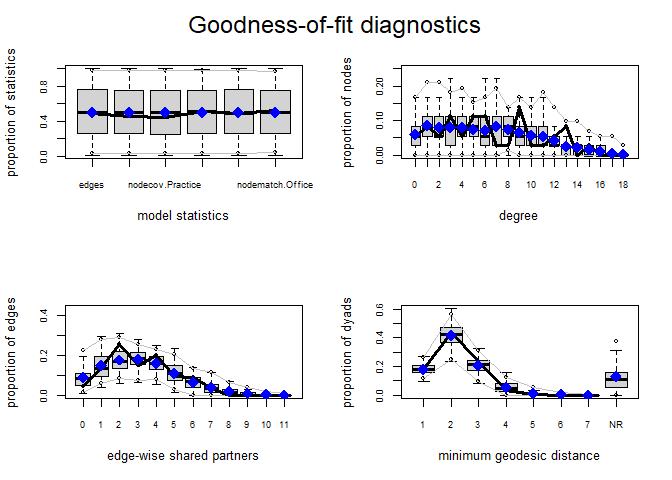

```r
gof.lazega.ergm <- gof(lazega.ergm.fit)
par(mfrow=c(2, 2))
plot(gof.lazega.ergm)
```

# 3 References

Krivitsky PN, Hunter DR, Morris M, and Klumb C (2023). “ergm 4: New Features for Analyzing Exponential-Family Random Graph Models.” *Journal of Statistical Software*, *105*(6), 1-44. doi:10.18637/jss.v105.i06

Kolaczyk, E. D., and Csárdi, G. (2014). Statistical analysis of network data with R (Vol. 65). New York: Springer.